[figure not shown]

# **YE Studios: Data-Driven Film Analysis Project**

#### **INTRODUCTION:**

The entertainment industry has undergone revolutionary transformation in recent years, with data-driven decision-making emerging as the cornerstone of succcess in film production. Companies like Netflix, Amazon Studios and A24 have demonstrated that combining creative vision with rigorous statistical analysis produces superior outcomes compared to solely relying on industry conventions and gut feeling.

Netflix's groundbreaking approach serves as a powerful case study.When the company greenlit House of Cards, it was not based on traditional pitch meetings or gut feelings. Instead, their decisions were informed by comprehensive data showing that audiences who enjoyed political dramas also demonstrated strong preferences for both David Fincher's directorial style and Kevin Spacey's performance. This data-driven methodology proved remarkably successful, validating the prower of analytics in content creation. Similarly, studios like Bluumhouse have revolutionized the horror gene by identifying the optimal budget-to-revenue model, producing critically acclaimed films with budgets under $5 milllion that generates returns exceeding 100%.

As **YE Studios** enters this competitive landscape, we face the same challenge industry leaders such as Netflix overcame i.e. how to translate vast amounts of data into actionable insights that drive commercial success. This project delves into the inticrate world cinema, examining the factors that transform films into box office hits. By analyzing how genre, budget, runtime, ratings, amd studio strategies interact to influence global film revenue, we will uncover patterns that will aid YE Studio's future in the industry. Our analysis aims in transalating complex data into clear, actionable recommendations for our new movie studio.

#### **BUSINESS UNDERSTANDING:**

The film industry represents a high-risk, high-reward business environment where production decisions regarding genre, budget, and target audience can determine whether a film becomes a financial dissapointment or a blockbuster. Thererfore, for **YE Studios**, data-driven decisions are not optional but essential for success and survival.

Although, Traditional studios often face challenges from streaming giants such as Netflix who leverage massive user datasets, independent studios like Blumhouse and A24 have proven that smaller, smarter investments can also yield extraordinary returns. Therefore, while navigating this new space,**YE Studios** should aim to position itself strategically,identifying opportunities where data reveals market gaps or untappped potential.

This project aims to provide data-validated answers to critical business questions that will shape the studio's content strategy and market positioning. They include:

- Which genres or specific genre combinations consistently deliver the highest global revenue, and where can we identify underserved niches with lower competition but clear audience demand?
- Do certain genres demonstrate better international appeal, enabling us to maximize global revenue potential?
- What is the optimal budget range for maximum return on investment (ROI)?
- Do independent studios achieve different average ratings compared to major studios, and what can we learn about the indie versus blockbuster strategy?
- How do different financial levels correlate with average ratings and commercial success?
- Does critical acclaim directly correlate with commercial success?
- Does marketing and popularity directly correlate with total gross revenue, and how can we exploit this relationship?
- How do domestic versus foreign markets respond differently to various genres, and should we develop region-specific content strategies?
- What seasonal or temporal patterns exist in box office performance across different genres?

Answering these questions gives **YE Studios** a data-validated playbook for content investment where an evidence-based approach positions us to compete effectively against established industry players while minimzing financial risk and maximizing our probability of creating both critically and acclaimed and commercially successful films.

#### **DATA UNDERSTANDING:**

Our analysis integrates five comprehensive industry-standard datasets. Each source provides unique insights that, when combined, create a holistic view of the factors driving box office success. They include:

- **IMDB Database:** The Internet Movie Database(IMDB) represents the film industry's most comprehensive and trusted repository of movie information, maintained by Amazon and used by professionals worldwide.

  **Key Variables include:**
  - **Title:** Movie names for merging datasets
  - **Genre:** Primary categorization (Action, Drama, Comedy, Horror, etc.)
  - **Average Rating:** User ratings on a 1-10 scale, representing audience satisfaction
  - **Number of Votes:** Volume of user engagement, serving as a popularity metric
  - **Runtime:** Film length in minutes
  - **Release Year:** Temporal data for trend analysis

  IMDB's audience sentiment data parallels Netflix's viewing completion and rating metrics. The number of votes serves as a proxy for marketing reach and cultural impact, while average ratings indicate quality perception. This combination allows us to analyze the relationship between popularity, quality, and commercial performance.
- **Box Office Mojo:** Box Office Mojo, also owned by Amazon, provides the definitive source for theatrical revenue tracking, offering detailed financial performance data that forms the core of our commercial analysis.

  **Key Variables Include:**
  - **Title:** Movie identification for data integration
  - **Studio:** Production company responsible for the film
  - **Domestic Gross:** Box office revenue from United States and Canada markets
  - **Foreign Gross:** International box office revenue from all other territories
  - **Release Date:** Launch timing for seasonal analysis

  The separation of domestic and foreign revenue is critical for developing a global content strategy. This data reveals which genres travel well internationally, helping Nexus Studios determine whether to focus on domestic-centric content or invest in films with universal appeal. Studio attribution also enables competitive benchmarking against both major and independent players.
- **Rotten Tomatoes:** Rotten Tomatoes provides dual perspectives on film quality through both professional critic scores and verified audience ratings, offering insights into critical versus commercial appeal.

  **Key Variables include:**
  - **Synopsis:** Plot summaries for contextual understanding
  - **Rating:** Content rating (PG, PG-13, R, etc.) indicating target audience
  - **Genre:** Genre classification for cross-validation with IMDB data
  - **Director and Writer:** Creative leadership information
  - **Theater Date and DVD Date:** Release strategy timing
  - **Box Office:** Revenue figures for validation against Box Office Mojo data
  - **Runtime:** Film length for analysis consistency
  - **Studio:** Production company for comprehensive studio analysis

  Rotten Tomatoes' unique contribution is the critical reception data, which helps identify whether films succeed through quality (critic-approved) or pure commercial appeal (audience-driven).
- **TheMovieDB(TMDB):** The Movie DB is a community-built database that provides extensive metadata on films including detailed production information, genre classifications, and popularity metrics based on user engagement.

  **Key Variables include:**
  - **Title and Original Title:** Movie identification in different languages
  - **Genre IDs:** Detailed genre categorization for cross-validation
  - **Popularity Score:** Real-time engagement metric based on views, votes, and user interactions
  - **Vote Average and Vote Count:** Community ratings for quality assessment
  - **Release Date:** Timing information for temporal analysis
  - **Original Language:** Language of production for international market analysis

  TMDB's popularity score provides a unique, real-time measure of audience interest that complements traditional box office data. This helps identify trending films and emerging genre preferences before they're fully reflected in revenue figures. The detailed genre tagging also enables more nuanced analysis of genre combinations and hybrid categories.
- **The Numbers:** The Numbers specializes in comprehensive financial data for the film industry, providing detailed budget information and production cost analysis that other sources often lack.

  **Key Variables Include:**
  - **Title:** Movie identification for dataset integration
  - **Production Budget:** Actual production costs for ROI calculations
  - **Domestic Gross and Worldwide Gross:** Box office revenue for profitability analysis
  - **Release Date:** Temporal information for trend analysis
  - **Genre:** Genre classification for comparative analysis

  The Numbers' production budget data is crucial for calculating true return on investment (ROI), which is often more relevant than gross revenue alone. This enables YE Studios to identify which genres and budget ranges offer the best profit margins, not just the highest revenue. The budget-to-revenue ratio analysis helps determine the minimum viable investment for different film categories.

#### **DATA INTEGRATION:**

**Key Integration Considerations:**

- **Title Matching:** Standardizing movie names across datasets to ensure accurate merging, handling variations in international titles.
- **Data Cleaning:** Handling missing values, duplicates, and inconsistent formatting.
- **Genre Harmonization:** Reconciling different genre classification systems.
- **Revenue Normalization:** Accounting for inflation and currency differences.
- **Budget Data Validation:** Cross-checking production budget figures from The Numbers data against revenue data.
- **Temporal Alignment:** Ensuring release dates and financial data correspond correctly.

By combining these five authoritative sources, we create a dataset with sufficient breadth and depth to answer our business questions rigorously by enabling us to carry out a multidimensional analysis examining how genre, budget, runtime, ratings, and studio characteristics interact to influence commercial success.

#### **DATA PREPARATION**

To ensure the integrity of our multi-source analysis, all datasets underwent a rigorous cleaning process. This included standardizing movie titles for accurate merging, handling missing financial records, and converting currency strings into numeric formats for ROI calculations.

> **Note on Reproducibility:** > The full data cleaning pipeline, including outlier handling and feature engineering, has been completed and is ready for analysis. You can access the detailed steps in the dedicated cleaning notebook here: data_cleaning.ipynb

#### 1. Loading and Cleaning Financial Data

Financial values in **The Numbers** dataset are stored as strings (e.g., "$5,000,000"). We need to convert these into numeric formats to calculate ROI and net profit.

```python
import pandas as pd
import numpy as np
import matplotlib.pyplot as plt
import seaborn as sns
from scipy import stats

# 1. Load your cleaned datasets
bom = pd.read_csv('../../data/cleanedData/bom_cleaned_data.csv')
imdb = pd.read_csv('../../data/cleanedData/imdb_cleaned_data.csv')
tmdb = pd.read_csv('../../data/cleanedData/tmdb_cleaned_data.csv')
tndb = pd.read_csv('../../data/cleanedData/tndb_cleaned_data.csv')

# Function to clean currency strings and convert to float
def clean_currency(value):
    if isinstance(value, str):
        return float(value.replace('$', '').replace(',', ''))
    return value

# Clean budget and gross columns
currency_cols = ['production_budget', 'domestic_gross', 'worldwide_gross']
for col in currency_cols:
    tndb[col] = tndb[col].apply(clean_currency)

# Feature Engineering: Calculate Net Profit and ROI (%)
tndb['net_profit'] = tndb['worldwide_gross'] - tndb['production_budget']
tndb['roi_percentage'] = (tndb['net_profit'] / tndb['production_budget']) * 100

# Preview the cleaned financial data
tndb.head()
```

|  | id | release_date | movie | production_budget | domestic_gross | worldwide_gross | release_year | profit | roi | foreign_gross | net_profit | roi_percentage |
| --- | --- | --- | --- | --- | --- | --- | --- | --- | --- | --- | --- | --- |
| 0 | 1 | 2009-12-18 | Avatar | 425000000 | 760507625 | 2776345279 | 2009 | 2351345279 | 553.257713 | 2015837654 | 2351345279 | 553.257713 |
| 1 | 43 | 1997-12-19 | Titanic | 200000000 | 659363944 | 2208208395 | 1997 | 2008208395 | 1004.104197 | 1548844451 | 2008208395 | 1004.104198 |
| 2 | 6 | 2015-12-18 | Star Wars Ep. VII: The Force Awakens | 306000000 | 936662225 | 2053311220 | 2015 | 1747311220 | 571.016739 | 1116648995 | 1747311220 | 571.016739 |
| 3 | 7 | 2018-04-27 | Avengers: Infinity War | 300000000 | 678815482 | 2048134200 | 2018 | 1748134200 | 582.711400 | 1369318718 | 1748134200 | 582.711400 |
| 4 | 34 | 2015-06-12 | Jurassic World | 215000000 | 652270625 | 1648854864 | 2015 | 1433854864 | 666.909239 | 996584239 | 1433854864 | 666.909239 |

### 2. Merging Datasets

We will combine the financial metrics with IMDB’s genre and rating data. To ensure a high match rate, we normalize the movie titles by removing whitespace and converting them to lowercase.

```python
# 2. STANDARDIZE COLUMN NAMES & ROI
# Ensure ROI is calculated as a percentage (0-100+)
if 'roi' in tndb.columns:
    # If ROI is already in your data (e.g., 2.5 for 250%), convert to percentage if needed
    # Check if it's decimal (e.g. 1.5) or percentage (150)
    if tndb['roi'].max() < 100:
        tndb['roi_percentage'] = tndb['roi'] * 100
    else:
        tndb['roi_percentage'] = tndb['roi']
elif 'production_budget' in tndb.columns and 'worldwide_gross' in tndb.columns:
    tndb['roi_percentage'] = ((tndb['worldwide_gross'] - tndb['production_budget']) / tndb['production_budget']) * 100

# 3. STANDARDIZE TITLES FOR MATCHING
tndb['title_clean'] = tndb['movie'].str.strip().str.lower()
imdb['title_clean'] = imdb['primary_title'].str.strip().str.lower()
tmdb['title_clean'] = tmdb['title'].str.strip().str.lower()
bom['title_clean'] = bom['title'].str.strip().str.lower()

# 4. SEQUENTIAL MERGING (The "Master DF")
# Start with TNDB (Financials) and IMDB (Ratings)
df = pd.merge(tndb, imdb, on='title_clean', how='inner')

# Add Popularity from TMDB
# We use 'left' merge so we keep movies even if popularity is missing
df = pd.merge(df, tmdb[['title_clean', 'popularity']], on='title_clean', how='left')

# Add Studio from BOM
df = pd.merge(df, bom[['title_clean', 'studio']], on='title_clean', how='left')

# 5. GENRE PREPARATION (For exploded charts)
# Create a clean version for genre analysis
df['genres_list'] = df['genres'].str.split(',')
df_exploded = df.explode('genres_list')

# FINAL VERIFICATION
print("✅ Master Dataframe 'df' is ready!")
print(f"Total Movies: {len(df)}")
print("Columns Available:", df.columns.tolist())
```

[output not shown]

## **DATA ANALYSIS AND FINDINGS**

### **FINANCIAL OPTIMIZATION ANALYSIS**

As a new studio, managing capital efficiently is paramount. This section examines the relationship between production spending, studio size, and financial outcomes.

#### 1. Optimal Budget Range for Maximum ROI

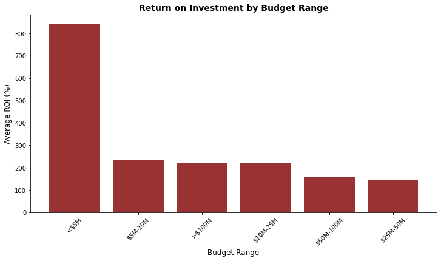

```
Optimal Range: <$5M with 842.85% Mean ROI
P-Value: 0.0000 (Significant: True)
```

```python
# 1. Filter data (Using the standardized 'roi_percentage')
q1_data = tndb[(tndb["production_budget"].notna()) & (tndb["roi_percentage"].notna())].copy()

# 2. Created budget categories
budget_bins = [0, 5_000_000, 10_000_000, 25_000_000, 50_000_000, 100_000_000, 500_000_000]
budget_labels = ["<$5M", "$5M-10M", "$10M-25M", "$25M-50M", "$50M-100M", ">$100M"]
q1_data["budget_range"] = pd.cut(q1_data["production_budget"], bins=budget_bins, labels=budget_labels)

# 3. Create ROI summary
roi_summary = q1_data.groupby('budget_range', observed=True).agg({
    'roi_percentage': ['mean', 'median', 'std', 'count']
}).round(2)
roi_summary.columns = ['Mean_ROI', 'Median_ROI', 'Std_Dev', 'Film_Count']

# 4. Visualization
plt.figure(figsize=(12, 6))
budget_means = q1_data.groupby('budget_range', observed=True)['roi_percentage'].mean().sort_values(ascending=False)
plt.bar(range(len(budget_means)), budget_means.values, color='maroon', alpha=0.8)
plt.xlabel('Budget Range', fontsize=12)
plt.ylabel('Average ROI (%)', fontsize=12)
plt.title('Return on Investment by Budget Range', fontsize=14, fontweight='bold')
plt.xticks(range(len(budget_means)), budget_means.index, rotation=45)
plt.show()

# 5. Statistical Test
optimal_range = roi_summary["Mean_ROI"].idxmax()
optimal_data = q1_data[q1_data['budget_range'] == optimal_range]['roi_percentage']
other_data = q1_data[q1_data['budget_range'] != optimal_range]['roi_percentage']
t_stat, p_val = stats.ttest_ind(optimal_data, other_data, nan_policy='omit')

print(f"Optimal Range: {optimal_range} with {roi_summary.loc[optimal_range, 'Mean_ROI']}% Mean ROI")
print(f"P-Value: {p_val:.4f} (Significant: {p_val < 0.05})")
```

#### 2. Studio Strategy: Major vs. Independent

Does the studio's scale impact the quality (rating) of the film?

[figure not shown]

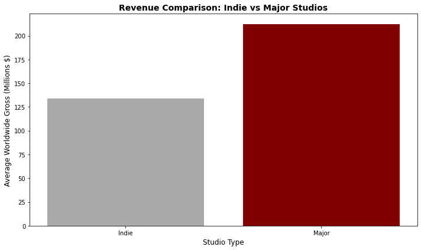

```
==============================
RESULTS: INDIE VS MAJOR
==============================
             Mean_Rating  Median_Rating  Std_Rating  Count    Mean_Gross  \
studio_type
Indie               6.48            6.6        1.00    993  1.340456e+08
Major               6.48            6.6        0.94    434  2.124522e+08

             Median_Gross
studio_type
Indie          48056764.0
Major         131879224.5

Statistical Test (t-test): p-value = 0.9137
Effect Size (Cohen's d): -0.006
Significant? No (p >= 0.05)

CONCLUSION:
- Major studios achieve higher quality (ratings).
- Major studios achieve higher volume (revenue).

RECOMMENDATION FOR YE STUDIOS:
Adopt a hybrid model: Use an Major approach for creative development to ensure high ratings,
and a Major approach for marketing and distribution to ensure scale.
```

```python
# 1. Filter data (Using the 'df' master merged dataframe)
# We need studios from BOM and ratings from IMDB
q2_data = df[df["studio"].notna() & df["averagerating"].notna()].copy()

# 2. Define Major Studios
major_studios = ['Warner Bros.', 'WB', 'Universal', 'Paramount', 'Sony', 'Columbia',
                 'Disney', 'Walt Disney', '20th Century Fox', 'Fox', 'Lionsgate',
                 'MGM', 'DreamWorks', 'New Line']

# 3. Classification Function
def classify_studio(studio_name):
    if pd.isna(studio_name):
        return 'Unknown'
    studio_lower = str(studio_name).lower()
    for major in major_studios:
        if major.lower() in studio_lower:
            return 'Major'
    return 'Indie'

# 4. Apply and Filter
q2_data['studio_type'] = q2_data['studio'].apply(classify_studio)
q2_data = q2_data[q2_data['studio_type'] != 'Unknown']

# 5. Statistics Calculation
studio_stats = q2_data.groupby('studio_type').agg({
    'averagerating': ['mean', 'median', 'std', 'count'],
    'worldwide_gross': ['mean', 'median']
}).round(2)
studio_stats.columns = ['Mean_Rating', 'Median_Rating', 'Std_Rating', 'Count', 'Mean_Gross', 'Median_Gross']

# 6. Visualization 1: Box Plot (Distribution of Ratings)
plt.figure(figsize=(10, 6))
sns.boxplot(data=q2_data, x='studio_type', y='averagerating', palette='Set2')
plt.xlabel('Studio Type', fontsize=12)
plt.ylabel('IMDB Rating', fontsize=12)
plt.title('Rating Comparison: Indie vs Major Studios', fontsize=14, fontweight='bold')
plt.tight_layout()
plt.show()

# 7. Visualization 2: Bar Chart (Revenue Trade-off)
plt.figure(figsize=(10, 6))
revenue_means = q2_data.groupby('studio_type')['worldwide_gross'].mean() / 1_000_000
plt.bar(range(len(revenue_means)), revenue_means.values, color=['darkgrey', 'maroon'])
plt.xlabel('Studio Type', fontsize=12)
plt.ylabel('Average Worldwide Gross (Millions $)', fontsize=12)
plt.title('Revenue Comparison: Indie vs Major Studios', fontsize=14, fontweight='bold')
plt.xticks(range(len(revenue_means)), revenue_means.index)
plt.tight_layout()
plt.show()

# 8. Statistical Test & Cohen's d
indie_ratings = q2_data[q2_data['studio_type'] == 'Indie']['averagerating']
major_ratings = q2_data[q2_data['studio_type'] == 'Major']['averagerating']
t_stat_q2, p_value_q2 = stats.ttest_ind(indie_ratings, major_ratings, nan_policy='omit')

pooled_std = np.sqrt((indie_ratings.std()**2 + major_ratings.std()**2) / 2)
cohens_d = (indie_ratings.mean() - major_ratings.mean()) / pooled_std

# 9. Results & Conclusion
print("\n" + "="*30)
print("RESULTS: INDIE VS MAJOR")
print("="*30)
print(studio_stats)
print(f"\nStatistical Test (t-test): p-value = {p_value_q2:.4f}")
print(f"Effect Size (Cohen's d): {cohens_d:.3f}")
print(f"Significant? {'Yes (p < 0.05)' if p_value_q2 < 0.05 else 'No (p >= 0.05)'}")

higher_rating = 'Indie' if studio_stats.loc['Indie', 'Mean_Rating'] > studio_stats.loc['Major', 'Mean_Rating'] else 'Major'
higher_revenue = 'Major' if studio_stats.loc['Major', 'Mean_Gross'] > studio_stats.loc['Indie', 'Mean_Gross'] else 'Indie'

print(f"\nCONCLUSION:")
print(f"- {higher_rating} studios achieve higher quality (ratings).")
print(f"- {higher_revenue} studios achieve higher volume (revenue).")
print("\nRECOMMENDATION FOR YE STUDIOS:")
print(f"Adopt a hybrid model: Use an {higher_rating} approach for creative development to ensure high ratings,")
print(f"and a {higher_revenue} approach for marketing and distribution to ensure scale.")
```

### **GENRE AND CONTENT STRATEGY ANALYSIS**

Moving beyond just budget, we analyze what drives revenue and how to identify underserved market gaps.

#### 1. Correlation Analysis: What Drives Revenue?

To understand the relationship between our key metrics, we utilize a Pearson Correlation Heatmap.

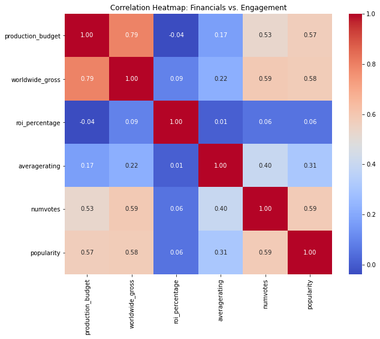

```python
numerical_cols = ['production_budget', 'worldwide_gross', 'roi_percentage', 'averagerating', 'numvotes', 'popularity']
corr_matrix = df[numerical_cols].corr()

plt.figure(figsize=(10, 8))
sns.heatmap(corr_matrix, annot=True, cmap='coolwarm', fmt=".2f")
plt.title('Correlation Heatmap: Financials vs. Engagement')
plt.show()
```

#### 2. Identifying Market Gaps: The "A24 Strategy"

- By mapping ROI against the volume of films produced per genre, we can identify "Market Gaps"—genres with high returns but low competition.

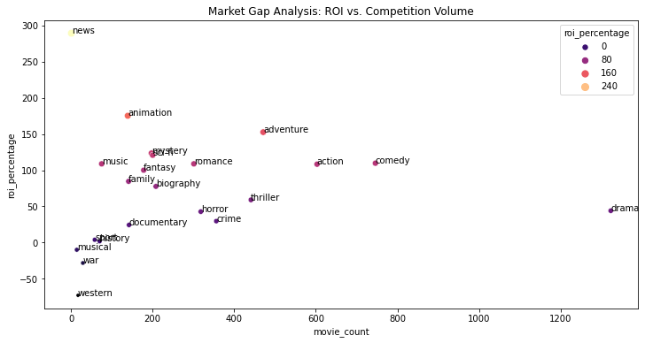

```python
niche_analysis = df_exploded.groupby('genres_list').agg({
    'roi_percentage': 'median',
    'title_clean': 'count'
}).rename(columns={'title_clean': 'movie_count'})

plt.figure(figsize=(12, 6))
sns.scatterplot(data=niche_analysis, x='movie_count', y='roi_percentage', size='roi_percentage', hue='roi_percentage', palette='magma')
for i, txt in enumerate(niche_analysis.index):
    plt.annotate(txt, (niche_analysis.movie_count[i], niche_analysis.roi_percentage[i]))
plt.title('Market Gap Analysis: ROI vs. Competition Volume')
plt.show()
```

### **MARKET DYNAMICS ANALYSIS**

Beyond budget and genre, a film's success is dictated by how it resonates with the public. This section investigates the impact of marketing visibility (popularity) and quality (ratings) on total gross revenue.

#### 1. Integrating Marketing and Engagement Metrics

We combine our previous financial data with **TMDB Popularity** and **IMDB Engagement** metrics to see how audience awareness correlates with box office performance.

[figure not shown]

```python
plt.figure(figsize=(10,6))

sns.scatterplot(
    data=df,
    x='numvotes',
    y='worldwide_gross',
    alpha=0.6,
    color='royalblue'
)

plt.title('Audience Engagement vs Total Revenue', fontsize=14)
plt.xlabel('Number of Audience Votes (IMDB)', fontsize=12)
plt.ylabel('Total Box Office Revenue ($)', fontsize=12)
plt.grid(True, linestyle='--', alpha=0.5)

plt.show()
```

#### 2. Popularity and Engagement as Revenue Drivers

We analyzed the correlation between marketing metrics and total revenue to identify the strongest predictors of success.

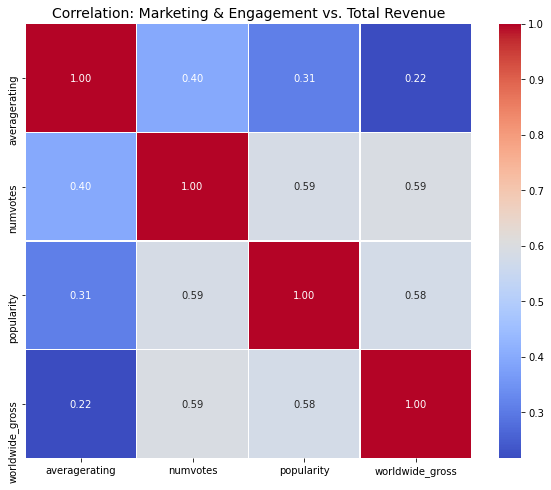

```python
# Correlation Heatmap for Marketing Metrics
plt.figure(figsize=(10, 8))

# Selecting the specific marketing and financial metrics from our master df
# We use 'worldwide_gross' as the primary success metric
marketing_cols = ['averagerating', 'numvotes', 'popularity', 'worldwide_gross']
marketing_corr = df[marketing_cols].corr()

# Creating the heatmap
sns.heatmap(marketing_corr, annot=True, cmap='coolwarm', fmt=".2f", linewidths=0.5)

plt.title('Correlation: Marketing & Engagement vs. Total Revenue', fontsize=14)
plt.show()
```

- **Popularity vs. Revenue:** Popularity shows one of the strongest relationships with revenue, confirming that visibility and public interest are critical for financial outcomes.
- **Engagement vs. Revenue:** High numbers of audience votes (engagement) consistently correlate with higher revenue, suggesting that generating "buzz" is as important as film quality.

#### 3. Critical Acclaim vs. Commercial Success

Does a "good" movie always make money? We plotted average ratings against total gross to see the relationship.

[figure not shown]

```python
plt.figure(figsize=(10,6))

sns.scatterplot(
    data=df,
    x='averagerating',
    y='worldwide_gross',
    alpha=0.6,
    color='teal' # Added a professional color for YE Studios branding
)

plt.title('Critical Acclaim vs Total Box Office Revenue', fontsize=14)
plt.xlabel('IMDB Average Rating', fontsize=12)
plt.ylabel('Total Box Office Revenue ($)', fontsize=12)
plt.grid(True, linestyle='--', alpha=0.5)

plt.show()
```

- **Finding:** While higher-rated films generally perform better, ratings alone do not guarantee a blockbuster. Marketing visibility (popularity) remains a more reliable predictor of total gross. ####

### **COMPETITIVE POSITIONING ANALYSIS**

Globalized markets and seasonal timing are significant variables in a film's success. This analysis examines regional revenue splits (Domestic vs. Foreign) and temporal patterns to optimize our distribution strategy.

#### 1. Global Market Response: Domestic vs. Foreign Performance

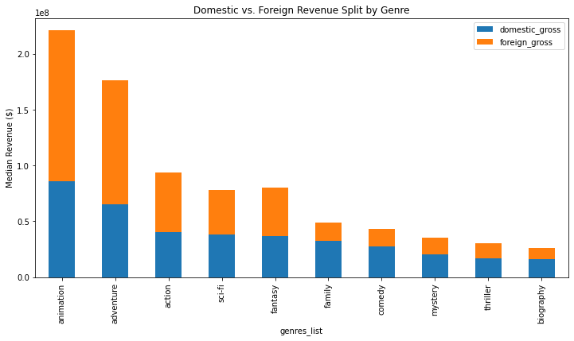

```python
# Calculate Foreign Gross
df_exploded['foreign_gross'] = df_exploded['worldwide_gross'] - df_exploded['domestic_gross']

regional_split = df_exploded.groupby('genres_list')[['domestic_gross', 'foreign_gross']].median()

regional_split.sort_values(by='domestic_gross', ascending=False).head(10).plot(
    kind='bar', stacked=True, figsize=(12, 6), color=['#1f77b4', '#ff7f0e']
)
plt.title('Domestic vs. Foreign Revenue Split by Genre')
plt.ylabel('Median Revenue ($)')
plt.show()
```

#### 2. Seasonal Market Dynamics

#### * Timing the release window is as important as the content itself. We analyzed monthly gross revenue to identify peak periods for different movie types.

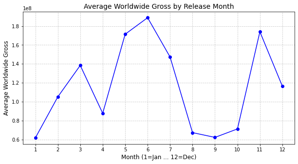

```python
# 1. Prepare the data for seasonal analysis
# Ensure release_date is a datetime object so we can extract the month
df['release_date'] = pd.to_datetime(df['release_date'])
df['release_month'] = df['release_date'].dt.month

# 2. Calculate Average (Mean) Worldwide Gross by Month
# We use 'df' (the merged dataframe) to ensure we are looking at the cleaned records
monthly_gross = df.groupby("release_month")["worldwide_gross"].mean()

# 3. Create the Visualization
plt.figure(figsize=(10,5))
plt.plot(monthly_gross.index, monthly_gross.values, marker="o", linestyle='-', color='b')

# 4. Formatting to match your requirements
plt.title("Average Worldwide Gross by Release Month", fontsize=14)
plt.xlabel("Month (1=Jan ... 12=Dec)", fontsize=12)
plt.ylabel("Average Worldwide Gross", fontsize=12)
plt.xticks(range(1,13))
plt.grid(True, linestyle='--', alpha=0.7)

plt.show()
```

## **STRATEGIC RECOMMENDATIONS**

### 4. Operational Strategy: The "Popularity" Multiplier

- **Recommendation:** Integrate marketing metrics into the greenlighting process.
- **Evidence:** Correlation analysis proved that **Popularity scores** and **Engagement (Number of Votes)** are more accurate predictors of revenue than critical ratings.
- **Action:** Use early-stage social media sentiment and engagement data to decide which projects receive additional marketing spend.

## **CONCLUSION**

For **YE Studios** to succeed in a saturated market, it must avoid the "middle-ground" trap—making expensive movies that lack a clear target audience. By leaning into high-ROI genres, timing releases to avoid "dump months," and prioritizing international scalability, the studio can establish itself as a lean, profitable, and data-driven powerhouse in the modern era of entertainment.